# HW7 Cheat Sheet

This is a cheat sheet for the seventh homework on affiliation. It works through each step in R.

First, you need the following packages.

```r
library(bibliometrix)
library(igraph)
library(ggplot2)
library(dplyr)
library(tidyr)
```

## 1. Introductory Inspection

First, we read the data. Next, you can answer most of the questions by analyzing the culture.df data frame. You can also easily provide an overview using the `biblioAnalysis` function of **Bibliometrix**. `summary` and `plot` will provide overviews to answer the introductory questions.

```r
culture.df <- readRDS("data/culture_corpus.RDS")

cul.bib <- biblioAnalysis(culture.df, sep=';')

summary(cul.bib, k=10)
```

```
MAIN INFORMATION ABOUT DATA

 Timespan                              1965 : 2022
 Sources (Journals, Books, etc)        6
 Documents                             996
 Annual Growth Rate %                  4.12
 Document Average Age                  20
 Average citations per doc             93.35
 Average citations per year per doc    4.691
 References                            53068

DOCUMENT TYPES
 article                         922
 article; proceedings paper      74

DOCUMENT CONTENTS
 Keywords Plus (ID)                    1951
 Author's Keywords (DE)                549

AUTHORS
 Authors                               1484
 Author Appearances                    1787
 Authors of single-authored docs       430

AUTHORS COLLABORATION
 Single-authored docs                  481
 Documents per Author                  0.671
 Co-Authors per Doc                    1.79
 International co-authorships %        9.739


Annual Scientific Production

 Year    Articles
    1965        3
    1966        2
    1967        7
    1968        7
    1969        3
    1970        3
```

[output cut: 129 more lines]

```


Most Relevant Keywords

   Author Keywords (DE)      Articles Keywords-Plus (ID)     Articles
1           CULTURE                36          CULTURE            144
2           GENDER                 12          UNITED-STATES      105
3           SOCIAL MOVEMENTS       11          INEQUALITY          56
4           INEQUALITY             10          SOCIOLOGY           56
5           EDUCATION               9          POLITICS            55
6           PUBLIC OPINION          8          GENDER              54
7           ORGANIZATIONS           7          ATTITUDES           53
8           RELIGION                7          IDENTITY            53
9           SOCIAL NETWORKS         7          RACE                51
10          IDENTITY                6          DEMOCRACY           39
```

[figure not shown]

[figure not shown]

[figure not shown]

[figure not shown]

[figure not shown]

```r
plot(x=cul.bib, k=5, pause=FALSE)
```

The bonus in the section can be constructed in ggplot. There are numerous ways to do this. I find the counts for each year and discpline by counting the rows using `n()` in the `summarise` function in **dplyr** and append it to a dataframe with just the counts by year using `bind_rows`.

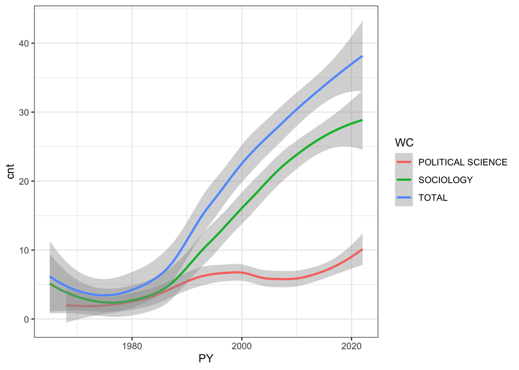

```r
dsum <- culture.df %>% group_by(WC, PY) %>% summarise(cnt = n())

tsum <- culture.df %>% group_by(PY) %>% summarise(cnt = n())

tsum$WC <- "TOTAL"

tsum <- bind_rows(tsum, dsum)

ggplot(data = tsum, aes(x=PY, y=cnt, group=WC, color=WC))  +
      geom_smooth(method = "loess") +
      theme_bw()
```

## 2. Culture in the Social Sciences

For this section I will build three different kinds of networks, but you can certainly build more.

### i.Co-authorship Network

First, I will build the co-authorship network. I’m going to build this network using the `cocMatrix` function.

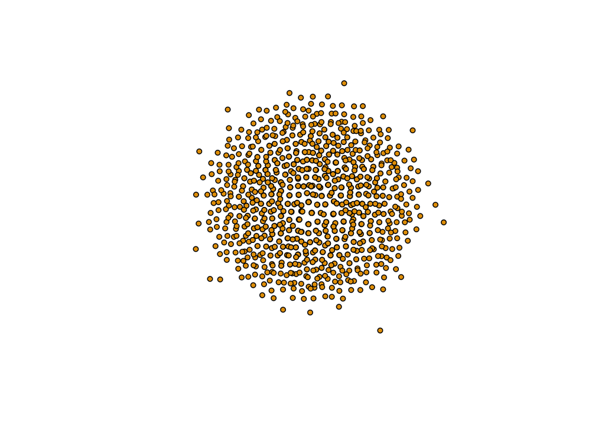

```r
#Use Bibliometrix to make a two-matrix of Articles X Authors

coauth <- cocMatrix(culture.df, Field="AU")

#Make an Igraph object from this matrix

coauth.2mode <- graph_from_biadjacency_matrix(coauth)

#Make a one-mode projection of this matrix looking at columns (Author X Author)

coauth.1mode <- bipartite_projection(coauth.2mode, multiplicity=TRUE, which=TRUE)

# Plot the one mode

plot(coauth.1mode, vertex.label=NA, vertex.size=4)
```

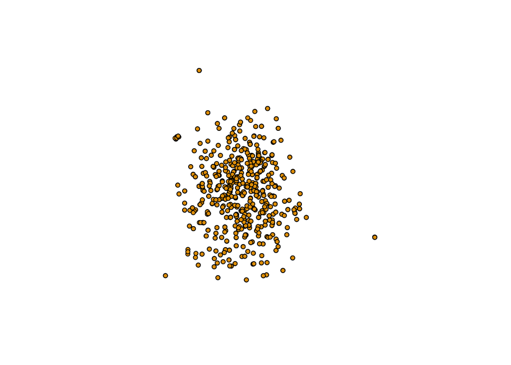

```r
# Let's get rid of isolates

coauth.noiso <- delete_vertices(coauth.1mode, which(degree(coauth.1mode)==0))

# and plot

plot(coauth.noiso, layout=layout_with_fr, vertex.label=NA, vertex.size=4)
```

```r
#can examine the components here

table(components(coauth.noiso)$csize)
```

```
  2   3   4   5   6   7   8   9  11  14  16  19
197  89  46  17   3   6   5   3   1   2   1   1
```

```r
#centralization

centr_degree(coauth.noiso)
```

```
$res
   [1]  3  2  7  2  7  2  1  3  5  4  5  6  2  6  3  3  6  6  3  9  1  4  2  2  1  5  3  2  3  3  1  3  1  2  4 18  2  4
  [39]  1  3  2  4  2  4  5  5  3  4  2  5  2  8  3  3  3  1  1  6  5  3  3  1  3  2  2  3  3  1  2  2  1  3  3  1  1  3
  [77]  2  3  1  4  3  7  1  2  1  1  1  2 15  1  3  7  1  2  2  2  2  3  2  3  1  1  3  2  4  3  2  4  3  6  3  1  2  1
 [115]  1  1  2  2  1  3  3  3  4  1  2  2  3  1  1  3  2  1  2  4  1  1 16  4  5  1  2  1  2  3  2  4  2  2  3  3  2  3
 [153]  1  1  4  1  7  3  1  2  2  1  1  3  1  3  2  2  1  2  2  3  2  3  1  4  1  5  7  4  1  1  5  3  2  1  1  3  3  1
 [191]  2  1  1  2  1  1  2  1  4  4  1  1  2  3  1  2  1  3  1  2  2  1  1  3  1 10  2  1  1  1  2  3  2  4  1  1  1  2
 [229]  1  1  4  1  2  2  2  1  1  1  4  2  2  1 13  1  1  1  1  4  1  5  2  3  3  4  2  1  1  2  1  3  1  2  2  2  1  1
 [267]  1  2  1  2  4  1  2  4  1  2  1  1  2  3  1  3  2  1  1  1  1  1  2  1  2  1  1  1  1  2  1  2  1  2  2  2  1  1
 [305]  1  2  2  2  2 13  1  2  2  2  2  1  3  2  2  1  2  1  1  1  2  2  2  2  1  1  1  1  2  3  3  1  1  1  1  4  1  1
 [343]  2  1  1  2  2  1  2  3  8  2  3  2  2  1  2  4  1  1  1  2  2  2 10  2  2  1  4  1  2  2  2  1  8  2  1  1  2  1
 [381]  2  1  1  1  2  1  1  2  2  2  4  3  1  1  1  2  1  4  1  2  1  2  1  1  2  1  1  2  2  2  2  2  1  1  1  3  1  1
 [419]  1  1  2  1  1  4  1 10  1  1  2  3  2  1  1  2  1  2  2  1  2  2  4  8  2  2  1  1  1  1 10  2  1  1  1  3  1  1
 [457]  4  1  2  1  1  1  1  8  1  1  2  1  1  1  3  2  1  2  2  2  1  2  1  2  1 13  1  3  1  1  1  1  1  1  2 13  1  1
 [495]  1  3  2  2  1  2  1  1  1  3  3  1  1  1  1  1  1  1  1  2  1  1  2  4  1  1  2  2  1  2  1  1  1  1  1 13  2  2
```

[output cut: 22 more lines]

```r
# density

edge_density(coauth.noiso)
```

```
[1] 0.001938922
```

### ii.Keyword 2-mode Network

Next, we can look at the keyword network in two modes.

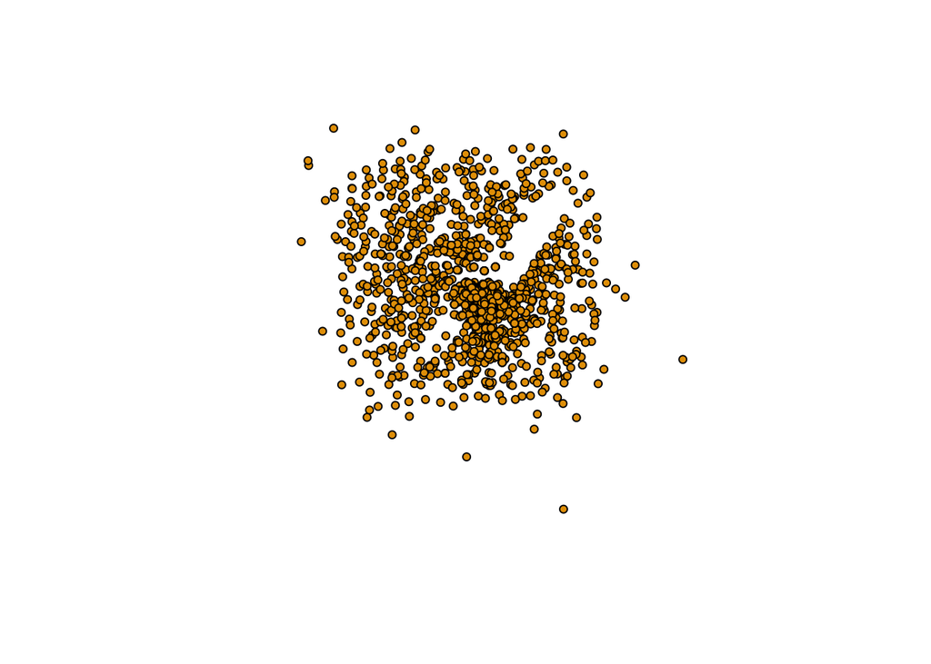

```r
kw.mat <- cocMatrix(culture.df, Field="DE")

kw.2mode <- graph_from_biadjacency_matrix(kw.mat)

# and plot

plot(kw.2mode, layout=layout_with_fr, vertex.label=NA, vertex.size=4)
```

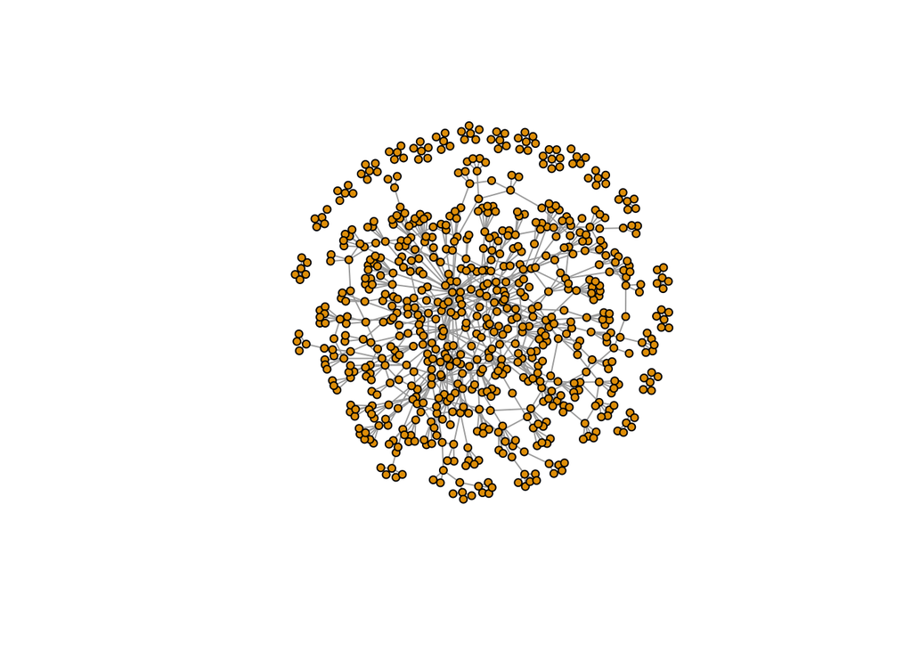

```r
# Let's get rid of isolates - Presumambly papers without keywords

kw2.noiso <- delete_vertices(kw.2mode, which(degree(kw.2mode)==0))

# and plot

plot(kw2.noiso, layout=layout_with_fr, vertex.label=NA, vertex.size=4)
```

```r
#can examine the components here

table(components(kw2.noiso)$csize)
```

```
  5   6   7   8 598
  5  11   1   1   1
```

```r
#centralization

centr_degree(kw2.noiso)
```

```
$res
  [1]  5  5  6  6  5  7  4  5  4  5  4  5  7  6  3  4  5  4  4  5  6  4  5  7  5  6  5  6  5  4  5  5  5  5  4  6  5  5
 [39]  5  4  5  5  4  5  5  5  5  7  7  5  5  6  4  4  4  6  4  5  5  5  5  5  5  5  5  6  5  4  7  5  5  5  5  5  6  5
 [77]  6  5  5  7  5  4  5  5  4  9  4  5  6  7  9  4  4  6  4  6  5  5  5  5  4  5  5  4  5  6  5 10  5  5  5  5  5  8
[115]  5  6  6  4  6  5  6  7  5  6  6  7  4  5  5  5  5  5  5  4  4  5  5  4  4  7  5  5  5  3  5  5  5  4  5  5  6 10
[153]  4  5  4 36 12 11 10  9  8  7  7  7  6  6  6  5  5  5  5  4  4  4  4  4  4  4  4  3  3  3  3  3  3  3  3  3  3  3
[191]  3  3  3  3  3  3  3  3  3  2  2  2  2  2  2  2  2  2  2  2  2  2  2  2  2  2  2  2  2  2  2  2  2  2  2  2  2  2
[229]  2  2  2  2  2  2  2  2  2  2  2  2  2  2  2  2  2  2  2  2  2  2  2  2  2  2  2  2  2  2  2  2  2  1  1  1  1  1
[267]  1  1  1  1  1  1  1  1  1  1  1  1  1  1  1  1  1  1  1  1  1  1  1  1  1  1  1  1  1  1  1  1  1  1  1  1  1  1
[305]  1  1  1  1  1  1  1  1  1  1  1  1  1  1  1  1  1  1  1  1  1  1  1  1  1  1  1  1  1  1  1  1  1  1  1  1  1  1
[343]  1  1  1  1  1  1  1  1  1  1  1  1  1  1  1  1  1  1  1  1  1  1  1  1  1  1  1  1  1  1  1  1  1  1  1  1  1  1
[381]  1  1  1  1  1  1  1  1  1  1  1  1  1  1  1  1  1  1  1  1  1  1  1  1  1  1  1  1  1  1  1  1  1  1  1  1  1  1
[419]  1  1  1  1  1  1  1  1  1  1  1  1  1  1  1  1  1  1  1  1  1  1  1  1  1  1  1  1  1  1  1  1  1  1  1  1  1  1
[457]  1  1  1  1  1  1  1  1  1  1  1  1  1  1  1  1  1  1  1  1  1  1  1  1  1  1  1  1  1  1  1  1  1  1  1  1  1  1
[495]  1  1  1  1  1  1  1  1  1  1  1  1  1  1  1  1  1  1  1  1  1  1  1  1  1  1  1  1  1  1  1  1  1  1  1  1  1  1
[533]  1  1  1  1  1  1  1  1  1  1  1  1  1  1  1  1  1  1  1  1  1  1  1  1  1  1  1  1  1  1  1  1  1  1  1  1  1  1
[571]  1  1  1  1  1  1  1  1  1  1  1  1  1  1  1  1  1  1  1  1  1  1  1  1  1  1  1  1  1  1  1  1  1  1  1  1  1  1
[609]  1  1  1  1  1  1  1  1  1  1  1  1  1  1  1  1  1  1  1  1  1  1  1  1  1  1  1  1  1  1  1  1  1  1  1  1  1  1
[647]  1  1  1  1  1  1  1  1  1  1  1  1  1  1  1  1  1  1  1  1  1  1  1  1  1  1  1  1  1  1  1  1  1  1  1  1  1  1
[685]  1  1  1  1  1  1  1  1  1  1  1  1  1  1  1  1  1  1  1  1

$centralization
[1] 0.04796004

$theoretical_max
[1] 494912
```

```r
# density

edge_density(kw2.noiso)
```

```
[1] 0.003249062
```

### iii. Keyword 1-mode Network

Now we can look at the keyword network in 1-mode

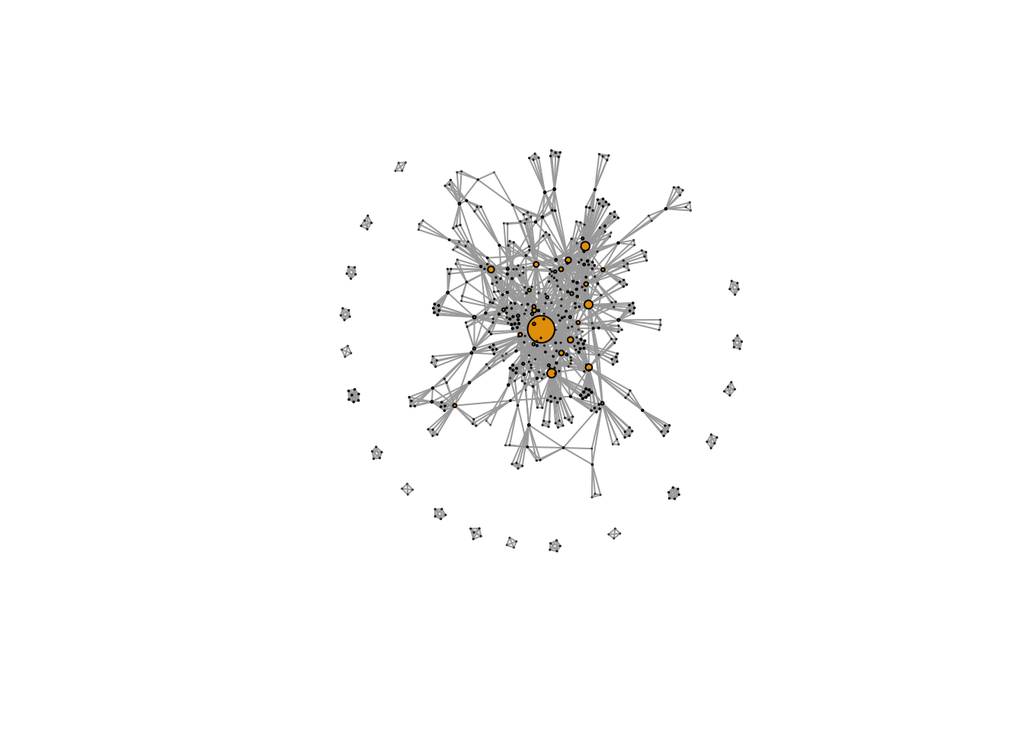

```r
kw.mat <- cocMatrix(culture.df, Field="DE")

kw.2mode <- graph_from_biadjacency_matrix(kw.mat)

kw.1 <- bipartite_projection(kw.2mode, multiplicity=TRUE, which="true")

plot(kw.1, vertex.label=NA, vertex.size=degree(kw.1)/10)
```

```r
#can examine the components here

table(components(kw.1)$csize)
```

```
  4   5   6   7 461
  5  11   1   1   1
```

```r
#centralization

centr_degree(kw.1)
```

```
$res
  [1] 135  44  45  42  29  32  33  26  29  25  22  21  18  22  19  18  17  15  16  14  14  14  16  18  10  12  13   9
 [29]  11  14  12  12  11  11  12  15  10  14  10  10  18  12  11  11   7   8   7   7   7   7   8   5   9   7  10   8
 [57]   7   6   6   7   9   7   9   7  10   7   7   9   9   6   9   7   9   8   9  14  11   9   7   9  11   8   6   9
 [85]  10  11  10  10   7   8  12   9   9   9   7   9  10   6  10   9  10   8   8   7   7   9   4   4   4   3   3   4
[113]   8   4   4   4   9   4   3   5   4   6   5   5   3   3   3   6   3   4   6   4   4   3   3   3   6   3   4   5
[141]   4   4   9   4   4   7   5   3   6   4   4   4   4   3   3   5   4   6   4   4   9   4   8   5   6   7   4   4
[169]   4   5   4   4   6   4   4   4   4   5   4   4   6   3   4   3   4   4   4   8   4   6   5   4   5   6   4   3
[197]   6   4   3   6   4   5   4   4   3   6   4   4   6   6   3   8   6   4   4   4   4   5   8   4   3   4   4   4
[225]   4   3   3   8   4   4   3   9   5   4   4   9   4   4   4   5   4   4   5   4   5   6   9   5   3   4   5   4
[253]   4   4   4   4   8   4   6   3   3   4   4   4   4   4   4   6   6   6   4   5   4   5   9   4   4   6   4   4
[281]   4   5   4   5   5   3   4   9   3   4   8   4   4   4   5   4   3   4   5   4   4   4   9   4   5   4   3   3
[309]   4   5   3   6   6   6   3   5   4   5   9   6   4   4   8   5   6   5   4   4   4   4   3   6   4   5   4   4
[337]   4   4   5   3   3   8   4   4   6   7   5   5   4   2   4   4   6   5   4   5   5   4   3   5   5   4   5   4
[365]   4   5   4   5   4   4   4   4   7   4   5   4   4   4   4   4   4   4   4   6   4   4   4   6   4   4   6   4
[393]   4   6   3   3   4   5   4   5   3   3   2   5   4   4   4   4   3   4   5   5   4   5   3   5   3   2   5   4
[421]   4   6   5   3   4   3   4   6   4   4   4   6   4   4   5   4   4   5   3   6   4   4   3   4   6   4   5   6
[449]   5   4   4   4   6   4   3   3   4   4   4   3   6   5   3   5   4   5   4   6   4   3   5   4   3   6   4   4
[477]   4   5   3   8   4   5   4   4   3   5   4   4   5   4   5   4   4   6   6   5   3   8   4   4   4   4   3   6
[505]   3   3   5   7   5   4   3   3   9   6   4   9   9   3   4   4   3   4   4   5   7   4   4   4   5   4   4   3
[533]   5   5   4   5   4   4   4   4   4   6   4   4   6   6   9   9   3

$centralization
[1] 0.2348563

$theoretical_max
[1] 300852
```

```r
# density

edge_density(kw.1)
```

```
[1] 0.01149402
```

## 2. Variation in Political Science and Sociology

### i. Variation in Coauthorship

This is a little bit of a challenge because we want to see if authors are political scientists or sociologists.

A simple and reasonable way to do it would be to pull out the giant connected component (or two given the kind of graph that we have) and inspect the authors in the component(s), perhaps by community.

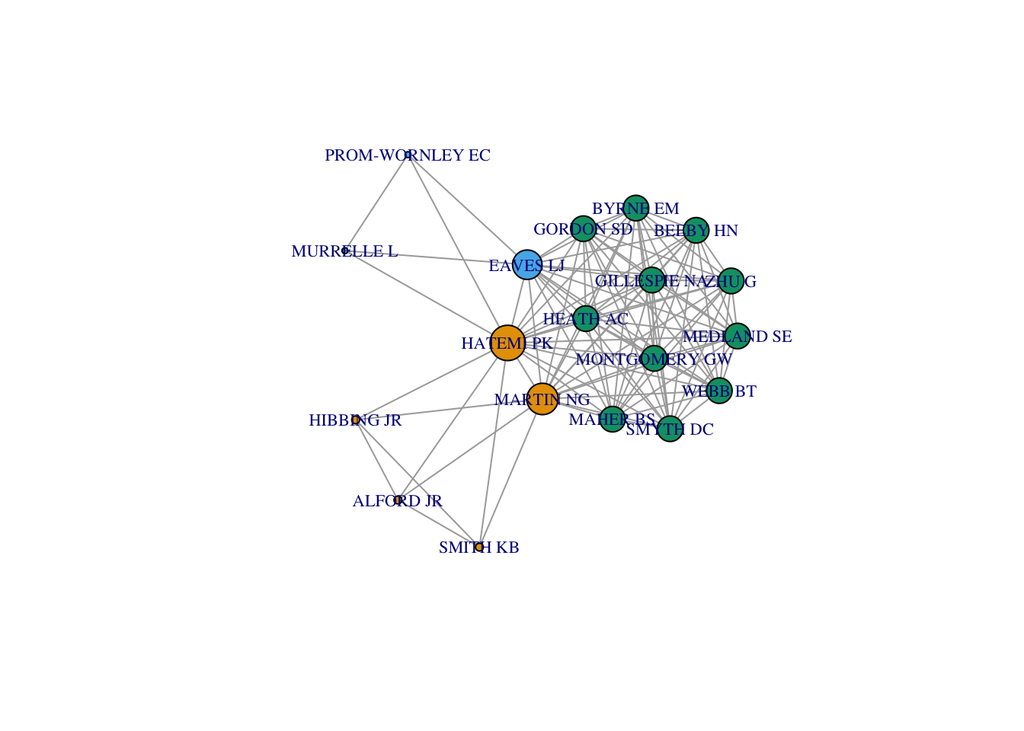

```r
comps <- components(coauth.noiso)

bigcomp <- which.max(comps$csize)

vert_ids <- V(coauth.noiso)[comps$membership == bigcomp]

gcc <- induced_subgraph(coauth.noiso, vert_ids)

comms <- cluster_louvain(gcc)

plot(gcc, layout=layout_with_kk, vertex.label.cex=.7, vertex.size=degree(gcc), vertex.color=as.factor(comms$membership))
```

If you want to look at the second largest component, you can identify it by size using a simple peek at component sizes in `table` and selecting the component size using `which` instead of `which.max`.

```r
table(comps$csize)
```

```
  2   3   4   5   6   7   8   9  11  14  16  19
197  89  46  17   3   6   5   3   1   2   1   1
```

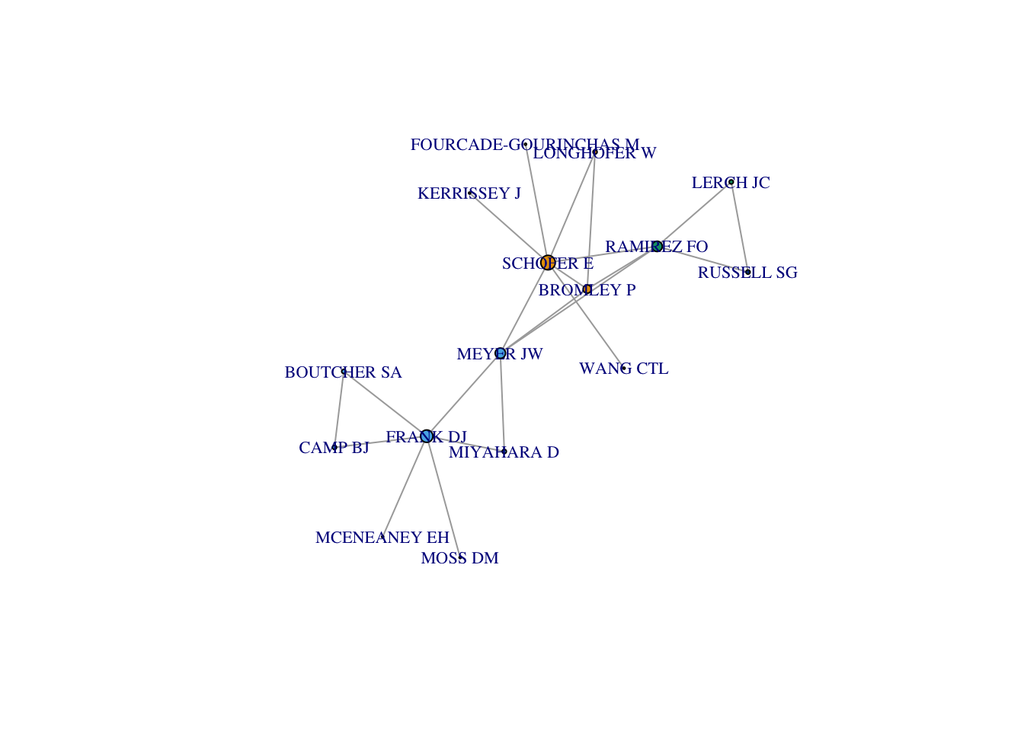

```r
secondcomp <- which(comps$csize==16)

vert_ids2 <- V(coauth.noiso)[comps$membership == secondcomp]

gcc2 <- induced_subgraph(coauth.noiso, vert_ids2)

comms2 <- cluster_louvain(gcc2)

plot(gcc2, layout=layout_with_kk, vertex.label.cex=.7, vertex.size=degree(gcc2), vertex.color=as.factor(comms2$membership))
```

Note that you can also program your way into connecting the field and the author data. It is a huge pain as you will see. You do not need to figure this out for this assignment. Lol.

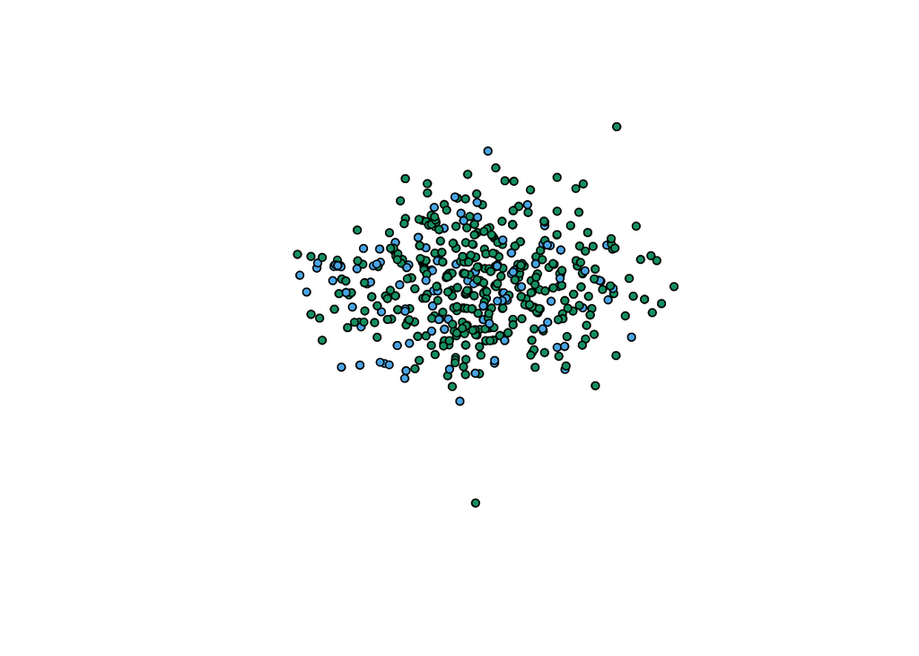

```r
# Not good practice to introduce here, but this part is extra in multiple ways.

library(tidyverse)
library(stringr)

aufields <- culture.df %>% select(AU, UT, WC)

mau <- max(str_count(aufields$AU, ";"))

ausplit <- as.data.frame(str_split_fixed(aufields$AU, ";", mau))

aufields$id <- 1:nrow(aufields)

ausplit$id <- 1:nrow(ausplit)

aufields <- left_join(aufields, ausplit)

aulong <- aufields %>% pivot_longer(V1:V13, names_to = "author_order", values_to = "author")

aulong <- aulong %>% filter(author!="")

auwc <- aulong %>% group_by(author, WC) %>% summarise(cnt = n())

ausoc <- auwc %>% filter(WC=="SOCIOLOGY")

ausoc <- rename(ausoc, soccnt=cnt)

ausoc <- ausoc %>% select(author, soccnt)

aupol <- auwc %>% filter(WC=="POLITICAL SCIENCE")

aupol <- rename(aupol, polcnt=cnt)

aupol <- aupol %>% select(author, polcnt)

autot <-aulong %>%  group_by(author) %>% summarise(cnt=n())

autot <- rename(autot, totcnt=cnt)

#put all data frames into list
df_list <- list(autot, aupol, ausoc)

#merge all data frames together
aus <- df_list %>% reduce(full_join, by='author')

aus[is.na(aus)] <- 0

aus$disc <- ifelse(aus$soccnt>0, "sociology", "political")

aus$disc <- ifelse(aus$totcnt!=aus$soccnt & aus$totcnt!=aus$polcnt, "both", aus$disc)

vname <- data.frame(author=V(coauth.noiso)$name)

vname <- left_join(vname, aus)

V(coauth.noiso)$discipline <- vname$disc

plot(coauth.noiso, layout=layout_with_fr, vertex.label=NA, vertex.size=4, vertex.color=as.factor(V(coauth.noiso)$discipline))
```